# dplyr Assignment

John Chandler

10/16/2020

## `dplyr` Practice

In this assignment we’ll re-do the queries from task 3 of the Wedge in `dplyr`. If you have uploaded your Wedge data already, write your queries against those tables.

I recommend testing your query against a single one of your tables and then using the trick from the `dplyr` class to query against all the tables. Further down I’ll provide a reminder of that trick.

In the Wedge project we pulled sales, transactions, and items across a variety of dimensions. In order to make this assignment a bit simpler, here we only need to gather the sales information. Also, after writing up the solutions, it occurs to me that this is a pretty ambitious assignment (particularly considering that you’re just coming off a tiring Wedge project), so I’m leaving the code for part 3, the hardest part, in the assignment. Consider it a Happy Halloween gift from me to you.

I recommend using `lubridate` for date manipulation and I have added that library into the includes.

In each section I ask you to record some observations about the plots that are made.

## Task 1: Sales by Date by Hour

Our data table has 38838 rows and 3 columns. Now let’s plot the sales by hour of the day for each of the years in the data.

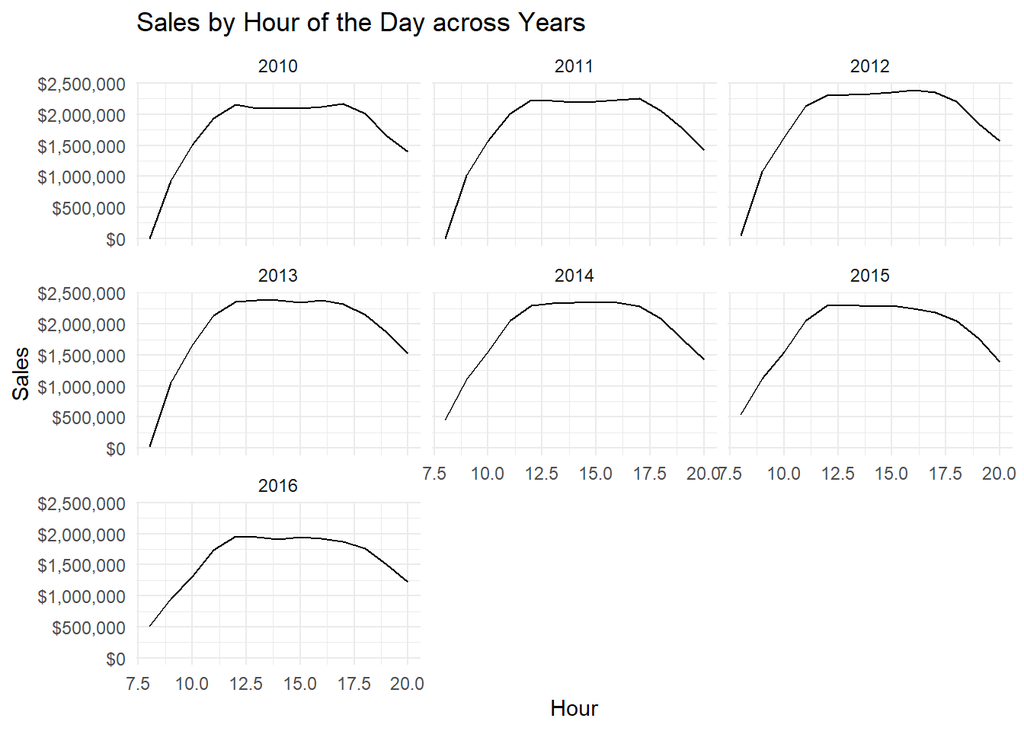

```r
d %>%
  mutate(year=year(date)) %>%
  group_by(year,hour) %>%
  summarize(sales = sum(sales)) %>%
  filter(year != 2017) %>%
  ggplot(aes(x=hour,y=sales)) +
  geom_line() +
  facet_wrap(~year) +
  theme_minimal() +
  labs(x="Hour",y="Sales",
       title="Sales by Hour of the Day across Years") +
  scale_x_continuous(limits=c(8,20)) +
  scale_y_continuous(label=dollar)
```

What features of the data stand out to you?

## Task 2: Sales by Owner, Year, and Month

In this section we’ll build a table of sales by owner, year, and month. Again, we’ll make a plot of it and again let’s exclude card number 3.

Our data table has 808811 rows and 4 columns. Now let’s plot the distribution of sales by card by year. Since this distribution is highly right skewed, we’ll plot it on a log scale.

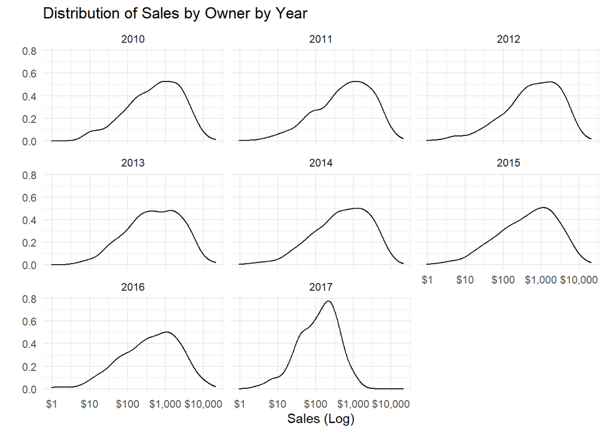

```r
d %>%
  group_by(card_no,year) %>%
  summarize(sales = sum(sales)) %>%
  ungroup() %>%
  slice_sample(prop=0.03) %>%  # Don't need all the data for density
  ggplot(aes(x=sales)) +
  geom_density() +
  facet_wrap(~year) +
  theme_minimal() +
  labs(x="Sales (Log)",y="",
       title="Distribution of Sales by Owner by Year") +
  scale_x_log10(label=dollar)
```

What features of the data stand out to you?

## Task 3: Sales by Product, Year, Month

```r
# First, let's get the top 100 product descriptions.
top.prods <- con %>%
  tbl("*") %>%
  filter(is.na(trans_status) |
           trans_status %in% c(" ","V","R"),
         !(department %in% c(0,15)),
         card_no != 3) %>%
  group_by(description) %>%
  summarize(sales = sum(total,na.rm=T)) %>%
  ungroup %>%
  arrange(desc(sales)) %>%
  head(n=100) %>%
  collect()

# Now let's pull sales by year and month for these products
d <- con %>%
  tbl("*") %>%
  filter(is.na(trans_status) |
           trans_status %in% c(" ","V","R"),
         !(department %in% c(0,15)),
         card_no != 3) %>%
  filter(description %in% !!top.prods$description) %>%
  select(description,datetime,total) %>%
  mutate(year=year(datetime),
         month=month(datetime)) %>%
  group_by(description,year,month) %>%
  summarize(sales=sum(total,na.rm=T)) %>%
  ungroup() %>%
  collect()
```

You may notice that organic bananas are in the data under two different names. It’s annoying, but let’s not worry about fixing that right now.

Our data table has 7050 rows and 4 columns. Now let’s plot the sales by month for just the top 10 products

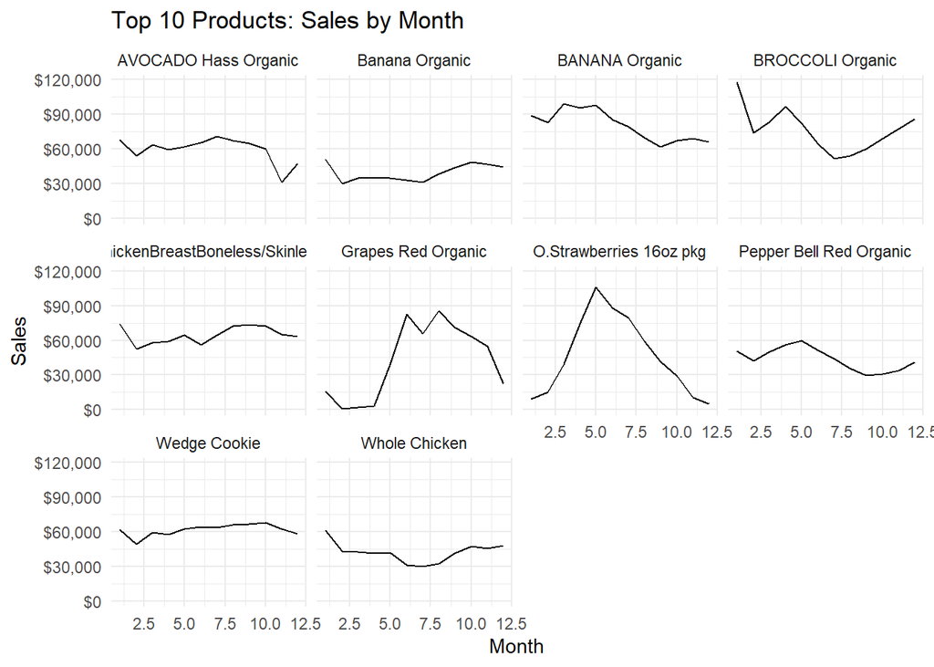

```r
top.ten <- head(top.prods$description,n=10)

d %>%
  filter(description %in% top.ten) %>%
  group_by(description, month) %>%
  summarize(sales = sum(sales, na.rm=T)) %>%
  ungroup() %>%
  ggplot(aes(x=month,y=sales)) +
  geom_line() +
  facet_wrap(~description) +
  theme_minimal() +
  labs(x="Month",y="Sales",
       title="Top 10 Products: Sales by Month") +
  scale_x_continuous() +
  scale_y_continuous(label=dollar)
```

What features of the data stand out to you?

## How to Query a Set of Tables

Typically in `dplyr` we write queries sort of like this:

```r
con <- dbConnect(
  bigrquery::bigquery(),
  project = "umt-msba",
  dataset = "transactions"
  )

trans.table <- tbl(con, "transArchive_201001_201003")

trans.table %>%
  group_by(card_no) %>%
  summarize(num_rows = n()) %>%
  collect()
```

To query *all* the tables in the data set, you can chain the connection and table lines together with the pipe:

```r
con <- dbConnect(
  bigrquery::bigquery(),
  project = "umt-msba",
  dataset = "transactions"
  )

con %>%
  tbl("*") %>%
  group_by(card_no) %>%
  summarize(num_rows = n()) %>%
  collect()
```